# Getting Started with the *ECODATA* Package

By the end of this vignette you will be able to download data from [FRED (Federal Reserve Economic Data)](https://fred.stlouisfed.org/) or [World Bank Data](https://data.worldbank.org/), create professional, publication-ready visualizations; and document your data, **and accomplish all of it with as little as three lines of code**.

# 1 About the Package

This package makes it easy to download and visualize economic data that is publicly available on [FRED (Federal Reserve Economic Data)](https://fred.stlouisfed.org/) or [World Bank Data](https://data.worldbank.org/). This package is a wrapper for three packages:

1. The [*fredr*](https://cran.r-project.org/web/packages/fredr/) package for downloading data from [FRED](https://fred.stlouisfed.org/).
2. The [*wbstats*](https://cran.r-project.org/web/packages/wbstats/) package for downloading data from [World Bank Data](https://data.worldbank.org/)
3. The [*ggplot2*](https://ggplot2.tidyverse.org/) package for visualizing data

The *ecodata* package is primarily targeted to novice R users and its primary intention to make the easy things easier. Still, experienced R users might find some of the procedures in this package convenient. With just two or three lines of code, you can use the package to download several variables from FRED and/or World Bank and make professional publication-ready plots. The package also provides a unified framework for downloading and plotting data from either source.

This package is not intended to replace *fredr* or *wbstats*. Those packages include a large amount of functionality which is not duplicated in this package. Experienced R programmers that have more than the simplest needs are best served from the underlying packages, *fredr*, *wbstats*, and *ggplot2*.

The package also does not replace browsing the [FRED](https://fred.stlouisfed.org/) or [World Bank Data](https://data.worldbank.org/) websites to explore and interact with data. In fact, the package provides the next step. After browsing and finding data you are interested in, you just need to copy and paste the URL(s) to retrieve the data using the functions in this package.

# 2 Installation

## 2.1 Install from Github

The package is available on Github at https://github.com/murraylax/ecodata. Use the *devtools* package to install directly in R:

```r
# install the devtools package, if necessary
install.packages("devtools")

# Install the ecodata package
devtools::install_github("murraylax/ecodata")`
```

## 2.2 Set up

Load the library:

```r
library(ecodata)
```

The package uses the FRED (Federal Reserve Economic Data) API, which requires an API key. If you have not already done so, you must create an account at https://fred.stlouisfed.org/, log in, then go to https://fredaccount.stlouisfed.org/apikeys to create an API key. Click the button, `+ Request API Key` and follow instructions. When complete, you will have an API key that will be a 32 character string with letters and numbers, similar to ‘abcd1234efgh5678ijkl9012mnop3456’ (this is a fictional key, it will not work to use exactly this string).

Set up the API key to use in the *ecodata* package (and/or the *fredr* package) by entering the following in the R console (replace the string with your own key):

```r
ecodata_set_fredkey("abcd1234efgh5678ijkl9012mnop3456")
```

You should only need to do the above once per machine, then the FRED API should be available every time you load R.

If you find that you need to set the FRED key again, you can do so directly from the *fredr* package.

```r
fredr::fredr_set_key("abcd1234efgh5678ijkl9012mnop3456")
```

# 3 Download and Plot your First Variable

## 3.1 Load libraries

To begin, let us load the *`tidyverse`* library to wrangle and manipulate the data, and then the *ecodata* package.

```r
library(tidyverse)
library(ecodata)
```

## 3.2 Download the data

Next, let’s download a variable from FRED and inspect it. We will download data on real GDP for the United States, which is available on FRED at https://fred.stlouisfed.org/series/GDPC1.

```r
gdp <- get_ecodata("https://fred.stlouisfed.org/series/GDPC1")
```

Here is a look at the first ten rows of the data set.

| Date | Real Gross Domestic Product |
| --- | --- |
| 1947-01-01 | 2,182.681 |
| 1947-04-01 | 2,176.892 |
| 1947-07-01 | 2,172.432 |
| 1947-10-01 | 2,206.452 |
| 1948-01-01 | 2,239.682 |
| 1948-04-01 | 2,276.690 |
| 1948-07-01 | 2,289.770 |
| 1948-10-01 | 2,292.364 |
| 1949-01-01 | 2,260.807 |
| 1949-04-01 | 2,253.128 |

## 3.3 Make a time series plot

You can use the `ggplot_ecodata_ts()` function with a single parameter to make a time series plot the data.

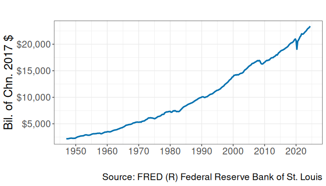

```r
ggplot_ecodata_ts(gdp)
```

Notice the default features such as a clean simple plot, large text that is ready for presentations, and the citation of the source of the data in the caption of the figure. These are elements of a `ggplot` that users could choose to change.

You can add a title one of two ways. The first is to pass the optional parameter, `title`:

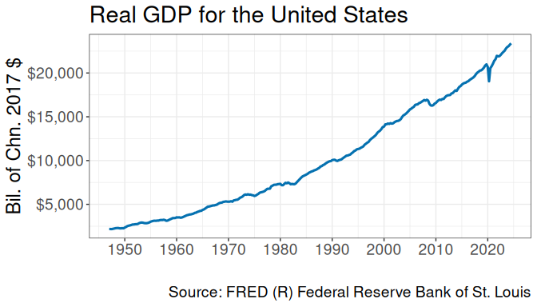

```r
ggplot_ecodata_ts(gdp, title = "Real GDP for the United States")
```

The other is to use the `labs()` function for adding or changing labels, which is provided by the *ggplot2* package. This approach is likely familiar to experienced R users.

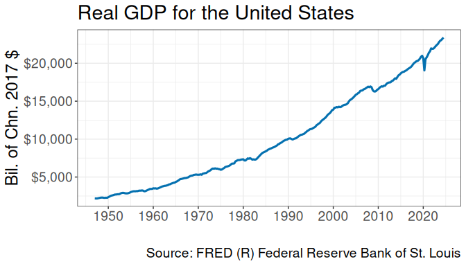

```r
ggplot_ecodata_ts(gdp) + labs(title = "Real GDP for the United States")
```

You can add NBER recession bars with one of two ways. The simplest is the addition of the optional `plot.recessions` parameter:

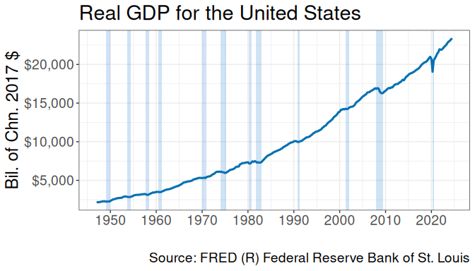

```r
# Include recession bars with a parameter
ggplot_ecodata_ts(gdp, title = "Real GDP for the United States", plot.recessions = TRUE)
```

R users already familiar with `ggplot()` may be more comfortable adding recession bars by adding a `geom_recession()`, a geom that is unique to this package.

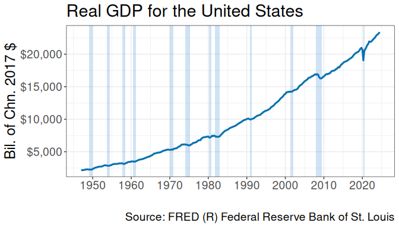

```r
# Include recession bars by adding a geom
ggplot_ecodata_ts(gdp) +
  labs(title = "Real GDP for the United States") +
  geom_recession()
```

## 3.4 Select date range

Use the tools in the *dplyr* package in combination with *ecodata* functions to select a range of dates to plot. Suppose we want to plot real GDP over the years 2000-2023. The code below starts with our data frame, filters out the appropriate dates, then passes the filtered data to `ggplot_ecodata_ts()`.

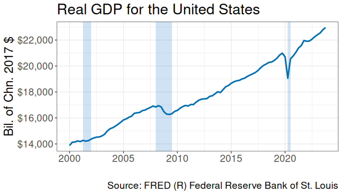

```r
gdp |>
  filter(Date >= "2000-01-01", Date <= "2023-12-31") |>
  ggplot_ecodata_ts(title = "Real GDP for the United States", plot.recessions = TRUE)
```

# 4 Multiple Variables

We can pull multiple variable from multiple sources all at once. Let’s consider the following variables:

- Income share held by the lowest 20% of the United States population, from World Bank Data: https://data.worldbank.org/indicator/SI.DST.FRST.20?locations=US
- Poverty rate in the United States, as a percentage of the population, from World Bank Data: https://data.worldbank.org/indicator/SI.POV.DDAY?locations=US
- Unemployment rate in the United States, from FRED: https://fred.stlouisfed.org/series/UNRATE

Some things to make note of that is usually complicated to work with:

- We have data from multiple sources, using different APIs
- We have mixed frequency data. The data from the World Bank is annual, while the unemployment data on FRED is monthly.

The *ecodata* package takes takes of these issues in the background.

## 4.1 Download the data

We can combine the three data sources together with the base R `c()` function.

```r
my_variables <- c(
  "https://data.worldbank.org/indicator/SI.DST.FRST.20?locations=US",
  "https://data.worldbank.org/indicator/SI.POV.DDAY?locations=US",
  "https://fred.stlouisfed.org/series/UNRATE"
)
```

Next, we’ll pass this vector of variables to the `get_ecodata()` function:

```r
mydata <- get_ecodata(my_variables)
```

Here is a look at the first twelve rows of the data set.

| Date | United States Income share held by lowest 20% | United States Poverty headcount ratio at $1.90 a day (% of population) | Unemployment Rate |
| --- | --- | --- | --- |
| 1948-01-01 |  |  | 3.4 |
| 1948-02-01 |  |  | 3.8 |
| 1948-03-01 |  |  | 4.0 |
| 1948-04-01 |  |  | 3.9 |
| 1948-05-01 |  |  | 3.5 |
| 1948-06-01 |  |  | 3.6 |
| 1948-07-01 |  |  | 3.6 |
| 1948-08-01 |  |  | 3.9 |
| 1948-09-01 |  |  | 3.8 |
| 1948-10-01 |  |  | 3.7 |
| 1948-11-01 |  |  | 3.8 |
| 1948-12-01 |  |  | 4.0 |

| Date | United States Income share held by lowest 20% | United States Poverty headcount ratio at $1.90 a day (% of population) | Unemployment Rate |
| --- | --- | --- | --- |
| 2021-05-01 |  |  | 5.8 |
| 2021-06-01 |  |  | 5.9 |
| 2021-07-01 |  |  | 5.4 |
| 2021-08-01 |  |  | 5.1 |
| 2021-09-01 |  |  | 4.7 |
| 2021-10-01 |  |  | 4.5 |
| 2021-11-01 |  |  | 4.1 |
| 2021-12-01 |  |  | 3.9 |
| 2022-01-01 | 5.2 | 1.2 | 4.0 |
| 2022-02-01 |  |  | 3.8 |
| 2022-03-01 |  |  | 3.6 |
| 2022-04-01 |  |  | 3.7 |

There is one observation over the year for the World Bank data, while there are observations for every month for unemployment data. This is expected.

## 4.2 Using different variable names

The variable names that the World Bank gives are rather long. It’s possible to specify our own variable names in the call to `get_ecodata()`. We will again set up the URLs for the data locations, and specify convenient variable names:

```r
my_variables <- c(
  "https://data.worldbank.org/indicator/SI.DST.FRST.20?locations=US",
  "https://data.worldbank.org/indicator/SI.POV.DDAY?locations=US",
  "https://fred.stlouisfed.org/series/UNRATE"
)

variable_names <- c(
  "Income Share of Bottom 20%",
  "Poverty Rate",
  "Unemployent Rate"
)

mydata <- get_ecodata(my_variables, variable_names)
```

Here is a slice of the data from 2021-2022.

| Date | Income Share of Bottom 20% | Poverty Rate | Unemployent Rate |
| --- | --- | --- | --- |
| 2021-05-01 |  |  | 5.8 |
| 2021-06-01 |  |  | 5.9 |
| 2021-07-01 |  |  | 5.4 |
| 2021-08-01 |  |  | 5.1 |
| 2021-09-01 |  |  | 4.7 |
| 2021-10-01 |  |  | 4.5 |
| 2021-11-01 |  |  | 4.1 |
| 2021-12-01 |  |  | 3.9 |
| 2022-01-01 | 5.2 | 1.2 | 4.0 |
| 2022-02-01 |  |  | 3.8 |
| 2022-03-01 |  |  | 3.6 |
| 2022-04-01 |  |  | 3.7 |

# 5 Plots with Multiple Variables

## 5.1 Time series plots

We can make a time series as before. The simplest way is to just call `ggplot_ecodata()`.

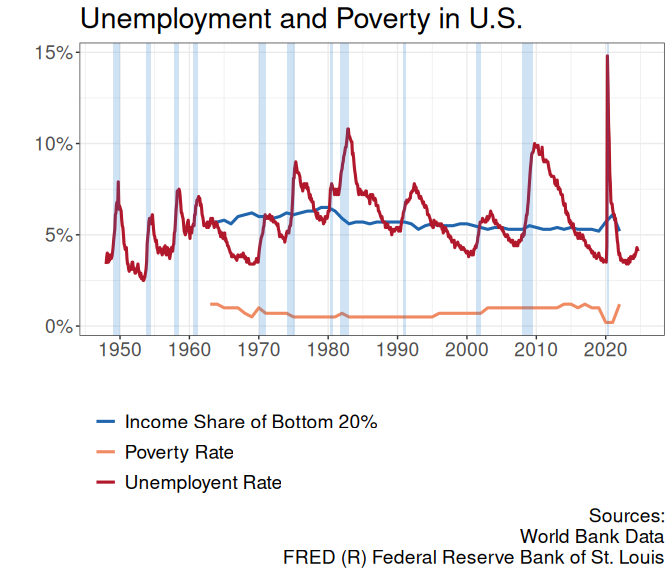

```r
ggplot_ecodata_ts(mydata, title = "Unemployment and Poverty in U.S.", plot.recessions = TRUE)
```

Note that each series is given its own color, and a legend appears at the bottom of the plot. The function `ggplot_ecodata_ts()` will allow for up to 7 series to plot in a single graph (but three is usually a good maximum to consider).

## 5.2 Faceted time series plots

Plotting multiple lines on a single plot is best when the variables are directly comparable. In the example in the previous subsection, all three variables are percentages, but the percentages for poverty rate, unemployment rate, and income share are not directly comparable. This is probably not the most convenient way to visualize these variables.

We can alternatively make a faceted plot using `ggplot_ecodata_facet()`, following a similar structure as above:

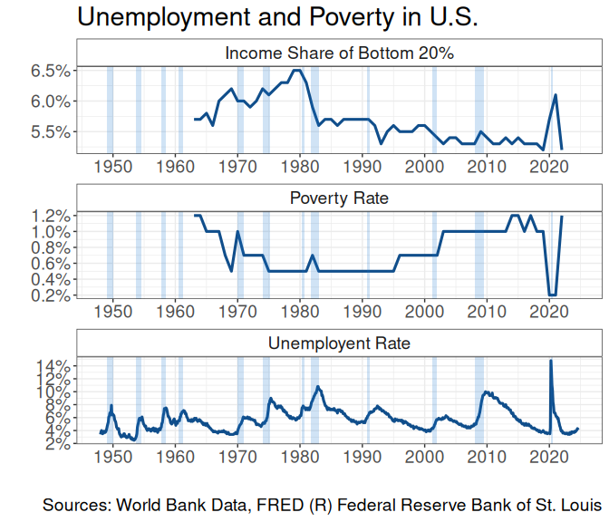

```r
ggplot_ecodata_facet(mydata,
                     title = "Unemployment and Poverty in U.S.",
                     ncol = 1,
                     plot.recessions = TRUE)
```

Note that we specified the multiple plots to appear in a single column, using the optional parameter, `ncol = 1`.

## 5.3 Plot only selected variables

With either time series plots or faceted plot, you can choose to only plot a selection of variables, using the `variables` parameter. Below we choose to only plot the two World Bank variables.

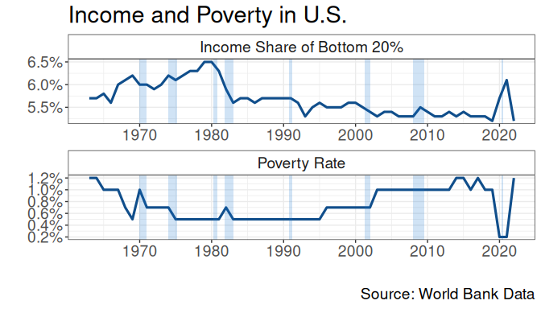

```r
ggplot_ecodata_facet(mydata,
                     variables = c("Income Share of Bottom 20%", "Poverty Rate"),
                     title = "Income and Poverty in U.S.",
                     ncol = 1,
                     plot.recessions = TRUE)
```

More experienced R users may be more comfortable using **dplyr** functions to select the data, then passing the selected data to the plot function. Using this strategy, it is necessary to select the `Date` variable, in addition to the variables of interest. The following code accomplishes the same as above:

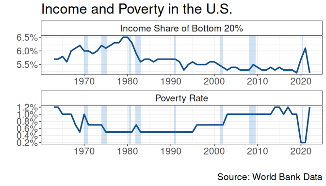

```r
mydata |>
  select(Date, `Income Share of Bottom 20%`, `Poverty Rate`) |>
  ggplot_ecodata_facet(title = "Income and Poverty in the U.S.", ncol = 1, plot.recessions = TRUE)
```

# 6 Multiple Locations

## 6.1 Multiple States

Here is the unemployment rate for California: https://fred.stlouisfed.org/series/CAUR. The following code downloads the unemployment rate for all 50 states:

```r
allstates <- get_ecodata_allstates_fred("https://fred.stlouisfed.org/series/CAUR")
```

We can take a `glimpse()` at the data to verify that we have a column for every U.S. state and the District of Columbia.

```r
glimpse(allstates)
```

```
#> Unemployment Rate in Each U.S. State
#> Rows: 585
#> Columns: 52
#> $ Date                       <date> 1976-01-01, 1976-02-01, 1976-03-01, 1976-0…
#> $ Alaska                     <dbl> 7.1, 7.1, 7.0, 6.9, 6.9, 7.1, 7.3, 7.6, 8.0…
#> $ Alabama                    <dbl> 6.6, 6.6, 6.6, 6.5, 6.4, 6.5, 6.6, 6.7, 6.8…
#> $ Arkansas                   <dbl> 7.3, 7.3, 7.3, 7.2, 7.1, 6.9, 6.8, 6.7, 6.6…
#> $ Arizona                    <dbl> 10.2, 10.2, 10.1, 10.0, 9.8, 9.7, 9.7, 9.6,…
#> $ California                 <dbl> 9.2, 9.2, 9.1, 9.1, 9.0, 9.0, 9.0, 9.1, 9.2…
#> $ Colorado                   <dbl> 5.8, 5.7, 5.7, 5.6, 5.6, 5.6, 5.8, 5.9, 6.1…
#> $ Connecticut                <dbl> 9.8, 9.8, 9.8, 9.6, 9.4, 9.3, 9.1, 9.0, 8.8…
#> $ `The District Of Columbia` <dbl> 8.7, 8.7, 8.6, 8.5, 8.4, 8.3, 8.4, 8.5, 8.7…
#> $ Delaware                   <dbl> 8.0, 8.0, 8.0, 8.1, 8.3, 8.6, 8.8, 8.9, 9.0…
#> $ Florida                    <dbl> 9.7, 9.7, 9.6, 9.5, 9.3, 9.2, 9.1, 9.1, 9.1…
#> $ Georgia                    <dbl> 8.4, 8.4, 8.4, 8.3, 8.1, 8.0, 8.0, 8.0, 8.0…
```

[output cut: 40 more lines]

Be cautious with this approach. The FRED API only allows a limited number of requests for given periods of time, before you have to wait to download again. FRED will return an error or a warning when you have reached this limit.

## 6.2 Multiple Countries

For World Bank data, you can download the same variable for multiple countries using the `get_ecodata_allcountries_wb()` function.

Here is poverty data for the United States: https://data.worldbank.org/indicator/SI.POV.DDAY?locations=US. The following code downloads the poverty rate for all countries:

```r
allcountries <- get_ecodata_allcountries_wb("https://data.worldbank.org/indicator/SI.POV.DDAY?locations=US")
```

We can take a `glimpse()` at the data to verify that we have a column for every country in the World Bank data set.

```r
glimpse(allcountries)
```

```
#>
#> Rows: 64
#> Columns: 218
#> $ Date                             <date> 1960-01-01, 1961-01-01, 1962-01-01, …
#> $ Afghanistan                      <dbl> NA, NA, NA, NA, NA, NA, NA, NA, NA, N…
#> $ Albania                          <dbl> NA, NA, NA, NA, NA, NA, NA, NA, NA, N…
#> $ Algeria                          <dbl> NA, NA, NA, NA, NA, NA, NA, NA, NA, N…
#> $ `American Samoa`                 <dbl> NA, NA, NA, NA, NA, NA, NA, NA, NA, N…
#> $ Andorra                          <dbl> NA, NA, NA, NA, NA, NA, NA, NA, NA, N…
#> $ Angola                           <dbl> NA, NA, NA, NA, NA, NA, NA, NA, NA, N…
#> $ `Antigua and Barbuda`            <dbl> NA, NA, NA, NA, NA, NA, NA, NA, NA, N…
#> $ Argentina                        <dbl> NA, NA, NA, NA, NA, NA, NA, NA, NA, N…
#> $ Armenia                          <dbl> NA, NA, NA, NA, NA, NA, NA, NA, NA, N…
#> $ Aruba                            <dbl> NA, NA, NA, NA, NA, NA, NA, NA, NA, N…
#> $ Australia                        <dbl> NA, NA, NA, NA, NA, NA, NA, NA, NA, N…
```

[output cut: 206 more lines]

There are many missing values (*NA* values) in the data set because the data is not available for all countries for all years.

# 7 Bar Plots

In the previous section, we downloaded data of poverty levels for all countries in the world. We can use the `ggplot_ecodata_bar()` function to make a bar plot to compare poverty levels for several different countries.

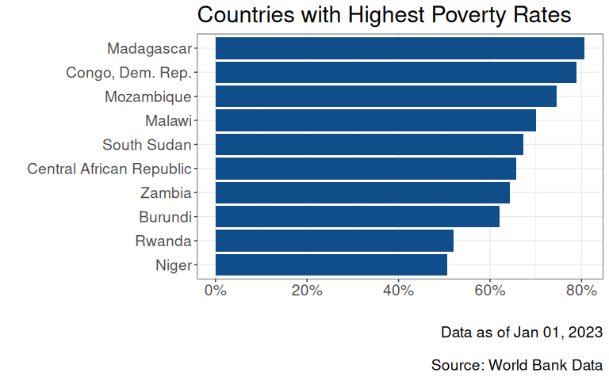

```r
ggplot_ecodata_bar(allcountries,
                   plot_at = "last",
                   highest = 10,
                   title = "Countries with Highest Poverty Rates")
```

It is also possible to highlight a particular country with the `highlight` parameter. Below we highlight Zambia.

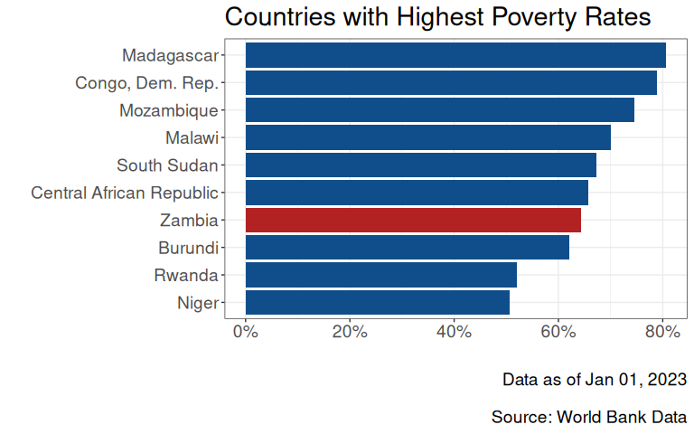

```r
ggplot_ecodata_bar(allcountries,
                   plot_at = "last",
                   highest = 10,
                   title = "Countries with Highest Poverty Rates",
                   highlight = "Zambia")
```

# 8 Data Transformations

You can use *ecodata* functions such as `ecodata_compute_pctchange()` an *ecodata*-specific `mutate()` function to compute data transformations.

## 8.1 Example Data

Let us demonstrate with data on real GDP, potential GDP, and the Consumer Price Index. First we download the data:

```r
variables <- c("https://fred.stlouisfed.org/series/GDPC1",
               "https://fred.stlouisfed.org/series/GDPPOT",
               "https://fred.stlouisfed.org/series/CPIAUCSL")

varnames <- c("Real GDP", "Potential GDP", "CPI")

mydata <- get_ecodata(variables, varnames = varnames)
```

## 8.2 Computing Growth Rate

The data on the Consumer Price Index is not too meaningful by itself, but the growth rate is the inflation rate for consumer prices. We can compute the growth rate of any variable with `ecodata_compute_pctchange()` as follows:

```r
mydata <- ecodata_compute_pctchange(mydata, variable = "CPI", new_variable = "Inflation")
```

This will create a new variable called `Inflation` that is equal to the year-over-year growth rate in the variable `CPI`.

Here we plot our new variable:

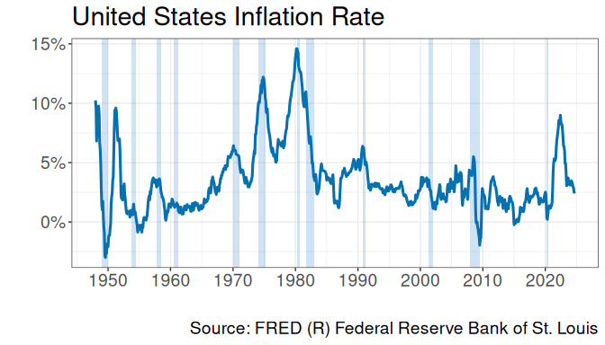

```r
ggplot_ecodata_ts(mydata, variables = "Inflation", title = "United States Inflation Rate", plot.recessions = TRUE)
```

## 8.3 Custom Data Transformation

Let us create a variable called `Output Gap` that is the difference between real GDP and potential GDP, as a percentage of potential GDP. We can use the `mutate()` function to do this. The `mutate()` function for *ecodata* data frames also takes as a parameter `units`, to specify what units to give the new variable. Since the output gap is a percentage, we set `units = "Percent"`.

```r
mydata <- mydata |>
  mutate(`Output Gap` = (`Real GDP` - `Potential GDP`) / `Potential GDP` * 100, units = "Percent")
```

Let use plot this variable:

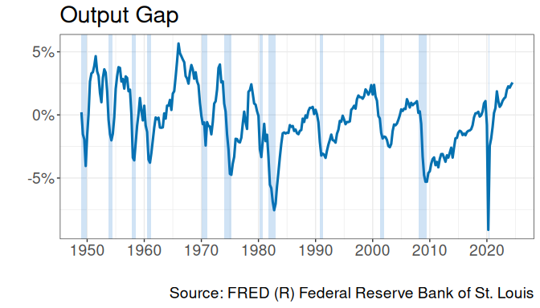

```r
ggplot_ecodata_ts(mydata, variables = "Output Gap", title = "Output Gap", plot.recessions = TRUE)
```

# 9 Data Documentation

## 9.1 Finding suggested citation

You can use `ecodata_cite_table()` to get citation information for an *ecodata* data frame. We get citation information for `mydata` from above as follows:

```r
ecodata_cite_table(mydata)
```

| Variable | Cite |
| --- | --- |
| Real GDP | FRED (R) Federal Reserve Bank of St. Louis; https://fred.stlouisfed.org/series/GDPC1; Accessed on October 31, 2024. |
| Potential GDP | FRED (R) Federal Reserve Bank of St. Louis; https://fred.stlouisfed.org/series/GDPPOT; Accessed on October 31, 2024. |
| CPI | FRED (R) Federal Reserve Bank of St. Louis; https://fred.stlouisfed.org/series/CPIAUCSL; Accessed on October 31, 2024. |
| Inflation | FRED (R) Federal Reserve Bank of St. Louis; https://fred.stlouisfed.org/series/CPIAUCSL; Accessed on October 31, 2024. |
| Output Gap | FRED (R) Federal Reserve Bank of St. Louis; https://fred.stlouisfed.org/series/GDPC1;https://fred.stlouisfed.org/series/GDPPOT; Accessed on October 31, 2024. |

## 9.2 Information about the variables

We can get more thorough information on our variables using `ecodata_description_table()`:

```r
ecodata_description_table(mydata)
```

| Variable | Code | Description | Frequency | Units | Seasonal Adjustment | Source | URL | Access Date |
| --- | --- | --- | --- | --- | --- | --- | --- | --- |
| Real GDP | GDPC1 | Real Gross Domestic Product | Quarterly | Bil. of Chn. 2017 $ | Seasonally Adjusted Annual Rate | FRED (R) Federal Reserve Bank of St. Louis | https://fred.stlouisfed.org/series/GDPC1 | October 31, 2024 |
| Potential GDP | GDPPOT | Real Potential Gross Domestic Product | Quarterly | Bil. of Chn. 2017 $ | Not Seasonally Adjusted | FRED (R) Federal Reserve Bank of St. Louis | https://fred.stlouisfed.org/series/GDPPOT | October 31, 2024 |
| CPI | CPIAUCSL | Consumer Price Index for All Urban Consumers: All Items in U.S. City Average | Monthly | Index 1982-1984=100 | Seasonally Adjusted | FRED (R) Federal Reserve Bank of St. Louis | https://fred.stlouisfed.org/series/CPIAUCSL | October 31, 2024 |
| Inflation | CPIAUCSL | Percent Change in Consumer Price Index for All Urban Consumers: All Items in U.S. City Average | Monthly | Percent | Seasonally Adjusted | FRED (R) Federal Reserve Bank of St. Louis | https://fred.stlouisfed.org/series/CPIAUCSL | October 31, 2024 |
| Output Gap |  | Computation = (`Real GDP` - `Potential GDP`)/`Potential GDP` * 100. | Quarterly | Percent | Seasonally Adjusted Annual Rate | FRED (R) Federal Reserve Bank of St. Louis | https://fred.stlouisfed.org/series/GDPC1; https://fred.stlouisfed.org/series/GDPPOT | October 31, 2024 |

The table includes descriptions provided by FRED or World Bank, and a number of other characteristics including frequency, units, seasonal adjustment status, and source.

# 10 Three Lines of Code

The *ecodata* package includes even more functionality than what is described in this document. For routine tasks, this package allows you to accomplish a lot with *just three lines of code*. Here is an example illustrating market interest rates for U.S. treasuries at 1-year and 10-year maturities.

```r
# Line 1: Download data
intrates <- get_ecodata(c("https://fred.stlouisfed.org/series/DGS1",
                          "https://fred.stlouisfed.org/series/DGS10"), frequency = "m")
```

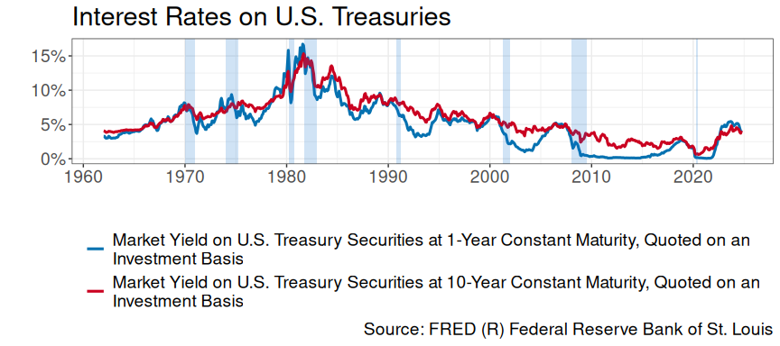

```r
# Line 2: Make a time series plot
ggplot_ecodata_ts(intrates, title = "Interest Rates on U.S. Treasuries", plot.recessions = TRUE)
```

```r
# Line 3: Cite my sources
ecodata_cite_table(intrates)
```

| Variable | Cite |
| --- | --- |
| Market Yield on U.S. Treasury Securities at 1-Year Constant Maturity, Quoted on an Investment Basis | FRED (R) Federal Reserve Bank of St. Louis; https://fred.stlouisfed.org/series/DGS1; Accessed on October 31, 2024. |
| Market Yield on U.S. Treasury Securities at 10-Year Constant Maturity, Quoted on an Investment Basis | FRED (R) Federal Reserve Bank of St. Louis; https://fred.stlouisfed.org/series/DGS10; Accessed on October 31, 2024. |